# OBER project BODAC filters and water

Pieter van Veelen

5/21/2021

## R Markdown

Analysis of microbial communities in BODAC filters and backwash water. Evaluate the effects of different DNA extraction methods. Pre-filters and polishing filters are referred to as BODAC1 and BODAC2, respectively, in the manuscript text and in figures (adjusted using Illustrator pre-submission).

### Set parameters and import data

#### Analysis of DNA concentrations

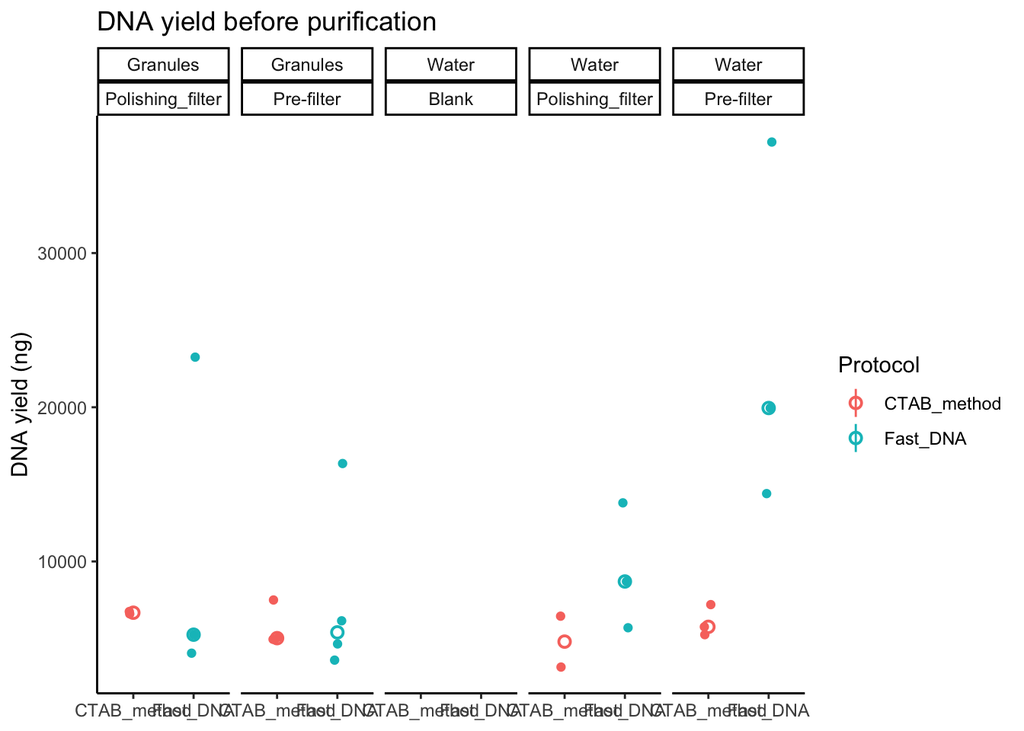

```r
dna_data <- read.table("input_data/OBER_DNA_conc_data.txt", header = T, sep = "\t", dec = ".") %>% as_tibble()
metadata_ps <- data.frame(sample_data(psdata_OBER)) %>% rownames_to_column(var = "SampleID") %>% as_tibble()
metadata_dna <- inner_join(dna_data, metadata_ps, by = "SampleID")

# metadata_dna %>%
#   pivot_longer(c(unpurified, purified), names_to = "Purification", values_to = "DNA_conc_ng_ul") %>%
#   mutate(dna_amount_ng = ifelse(Purification == "unpurified", DNA_conc_ng_ul*30,
#                                 DNA_conc_ng_ul*20)) %>%
#   ggplot(aes(x = combined, y = dna_amount_ng)) +
#   geom_point(aes(color = Protocol), position = position_jitterdodge(0.2), pch=21) +
#   facet_wrap(~Purification + Filter_type) +
#   theme_classic() +
#   theme(axis.text.x = element_text(angle = 90, hjust = 0))
#   theme(axis.text.x = element_text(angle = 90, hjust = 0))

metadata_dna %>%
  pivot_longer(c(unpurified, purified), names_to = "Purification", values_to = "DNA_conc_ng_ul") %>%
  mutate(dna_amount_ng = ifelse(Purification == "unpurified", DNA_conc_ng_ul*30,
                                DNA_conc_ng_ul*20)) %>%
  filter(Purification == "unpurified") %>%
  ggplot(aes(x = Protocol, y = dna_amount_ng, color = Protocol)) +
  geom_point(position = position_jitterdodge(0.2), show.legend = F) +
  stat_summary(fun = median, pch = 21) +
  facet_grid(~Sample_type + Filter_type) +
  theme_classic() +
  labs(y = "DNA yield (ng)", x = NULL) +
  #theme(legend.position = "bottom") +
  ggtitle("DNA yield before purification")
```

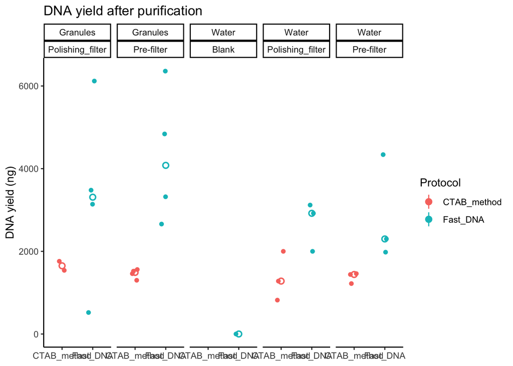

```r
metadata_dna %>%
  pivot_longer(c(unpurified, purified), names_to = "Purification", values_to = "DNA_conc_ng_ul") %>%
  mutate(dna_amount_ng = ifelse(Purification == "unpurified", DNA_conc_ng_ul*30,
                                DNA_conc_ng_ul*20)) %>%
  filter(Purification == "purified") %>%
  ggplot(aes(x = Protocol, y = dna_amount_ng, color = Protocol)) +
  geom_point(position = position_jitterdodge(0.3)) +
  stat_summary(fun = median, pch = 21) +
  facet_grid(~Sample_type + Filter_type) +
  labs(y = "DNA yield (ng)", x = NULL) +
  theme_classic() +
  #theme(legend.position = "bottom") +
  ggtitle("DNA yield after purification")
```

```r
# # tabulate loss
# metadata_dna %>%
#   mutate(loss_ng = (purified*20)-(unpurified*30)) %>%
#   group_by(Protocol, Sample_type, Filter_type) %>%
#   summarize(median_hilow(loss_ng))
#
# # plot loss
# metadata_dna %>%
#   mutate(loss_ng = (purified*20)-(unpurified*30)) %>%
#   ggplot(aes(y = loss_ng, x = Protocol, color = Sample_type)) +
#   geom_point() +
#   facet_wrap(~Filter_type) +
#   theme_classic()

# statistics
# unpurified
# water only
metadata_dna %>%
  pivot_longer(c(unpurified, purified), names_to = "Purification", values_to = "DNA_conc_ng_ul") %>%
  mutate(dna_amount_ng = ifelse(Purification == "unpurified", DNA_conc_ng_ul*30,
                                DNA_conc_ng_ul*20)) %>%
  filter(Purification == "unpurified",
         Sample_type == "Water") %>%
  with(kruskal.test(dna_amount_ng ~ Protocol))
```

```
##
##  Kruskal-Wallis rank sum test
##
## data:  dna_amount_ng by Protocol
## Kruskal-Wallis chi-squared = 4.8, df = 1, p-value = 0.02846
```

```r
# granules
metadata_dna %>%
  pivot_longer(c(unpurified, purified), names_to = "Purification", values_to = "DNA_conc_ng_ul") %>%
  mutate(dna_amount_ng = ifelse(Purification == "unpurified", DNA_conc_ng_ul*30,
                                DNA_conc_ng_ul*20)) %>%
  filter(Purification == "unpurified",
         Sample_type == "Granules") %>%
  with(kruskal.test(dna_amount_ng ~ Protocol))
```

```
##
##  Kruskal-Wallis rank sum test
##
## data:  dna_amount_ng by Protocol
## Kruskal-Wallis chi-squared = 0.18418, df = 1, p-value = 0.6678
```

```r
#purified
# water only
metadata_dna %>%
  pivot_longer(c(unpurified, purified), names_to = "Purification", values_to = "DNA_conc_ng_ul") %>%
  mutate(dna_amount_ng = ifelse(Purification == "unpurified", DNA_conc_ng_ul*30,
                                DNA_conc_ng_ul*20)) %>%
  filter(Purification == "purified",
         Sample_type == "Water") %>%
  with(kruskal.test(dna_amount_ng ~ Protocol))
```

```
##
##  Kruskal-Wallis rank sum test
##
## data:  dna_amount_ng by Protocol
## Kruskal-Wallis chi-squared = 3.7296, df = 1, p-value = 0.05346
```

```r
# granules only
metadata_dna %>%
  pivot_longer(c(unpurified, purified), names_to = "Purification", values_to = "DNA_conc_ng_ul") %>%
  mutate(dna_amount_ng = ifelse(Purification == "unpurified", DNA_conc_ng_ul*30,
                                DNA_conc_ng_ul*20)) %>%
  filter(Purification == "purified",
         Sample_type == "Granules") %>%
  with(kruskal.test(dna_amount_ng ~ Protocol))
```

```
##
##  Kruskal-Wallis rank sum test
##
## data:  dna_amount_ng by Protocol
## Kruskal-Wallis chi-squared = 5.4, df = 1, p-value = 0.02014
```

```r
### read in new purity data by OBER
# Test for differences in purity between purified and unpurified samples stratified by granules and water, and without blanks.
```

#### calculate rarefaction curves using amp_rarecurve.r

```r
# full dataset
psdata_OBER
```

```
## phyloseq-class experiment-level object
## otu_table()   OTU Table:         [ 3009 taxa and 34 samples ]
## sample_data() Sample Data:       [ 34 samples by 11 sample variables ]
## tax_table()   Taxonomy Table:    [ 3009 taxa by 7 taxonomic ranks ]
## phy_tree()    Phylogenetic Tree: [ 3009 tips and 3008 internal nodes ]
```

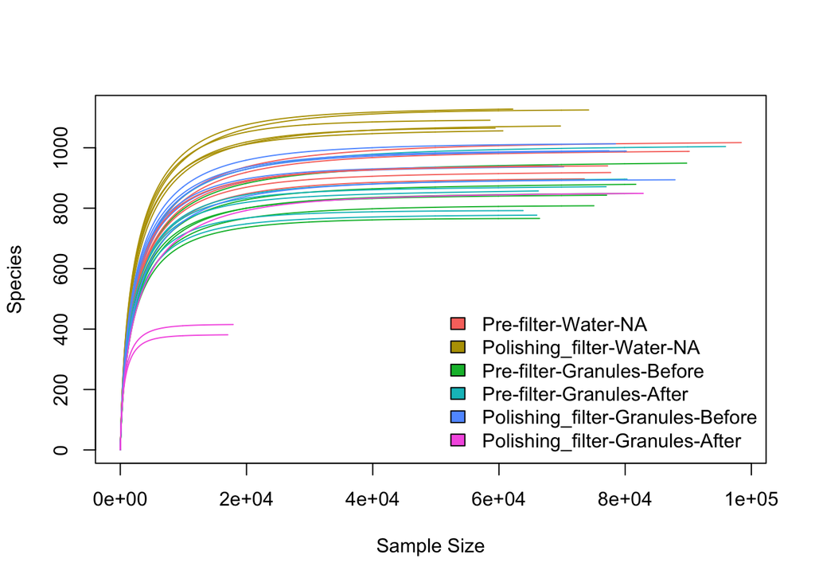

```r
psdata_OBER <- subset_samples(psdata_OBER, Filter_type != "Blank")

# relative abundance data
psdata_OBER_rel <- transform_sample_counts(psdata_OBER, fun = function(x) x/sum(x)) # 3009 taxa (100% abundance)

# abundance filter at (0.01%, 0.1% 0.5%)
psdata_OBER_0.01pct <- prune_taxa(taxa_sums(psdata_OBER_rel) > 0.0001, psdata_OBER) #2610 (99.94% abundance)
psdata_OBER_0.1pct <- prune_taxa(taxa_sums(psdata_OBER_rel) > 0.001, psdata_OBER) #1615 (98.73% abundance)
psdata_OBER_0.5pct <- prune_taxa(taxa_sums(psdata_OBER_rel) > 0.005, psdata_OBER) #2610 (93.07% abundance)

### choice to continue downstream analysis with abundance filter that retains ASVs with at least 0.1% of total read abundance.
psdata_OBER_unfiltered <- psdata_OBER # save unfiltered data
psdata_OBER <- psdata_OBER_0.1pct # overwrite psdata_OBER for abundance filtered data

# reformat metadata
metadata <- data.frame(sample_data(psdata_OBER), stringsAsFactors = T)
metadata$Sample_type <- as.factor(metadata$Sample_type)
metadata$Filter_type <- as.factor(metadata$Filter_type)
metadata$Time <- as.factor(metadata$Time)
metadata$Protocol <- as.factor(metadata$Protocol)

# alpha rarefaction curve
source("scripts/ampvis2_internals.r")
source("scripts/amp_rankabundance.r")
source("scripts/amp_rarecurve.r")

amp_rarecurve(psdata_OBER_unfiltered, color = "combined", legend.position = "bottomright")
```

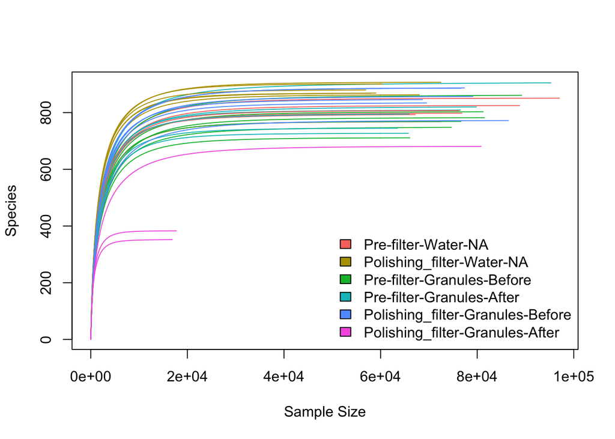

```r
amp_rarecurve(psdata_OBER, color = "combined", legend.position = "bottomright")
```

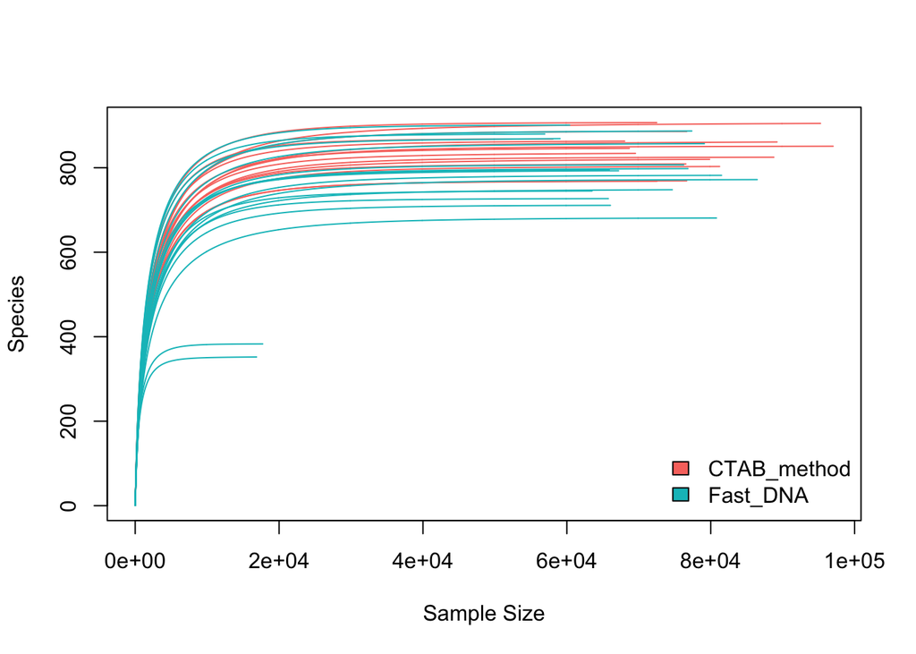

```r
amp_rarecurve(psdata_OBER, color = "Protocol", legend.position = "bottomright")
```

```r
# calculate richness
alpha <- estimate_richness(psdata_OBER, measures = c("Chao1", "Shannon"))
alpha$sampleID <- row.names(alpha)
metadata$sampleID <- sample_names(psdata_OBER)
alpha <- left_join(metadata, alpha, by = "sampleID")
Chao1 <- alpha %>%
  ggplot(aes(x=combined, y=Chao1, color = combined, shape = Protocol)) +
  geom_jitter(aes(group = Protocol), position = position_dodge(0.3), show.legend = T) +
  #geom_bar(stat="identity") +
  theme(axis.text.x = element_text(angle = 90, hjust = 0)) +
  theme(legend.text = element_markdown(),
        legend.key.size = unit(7, "pt"),
        axis.ticks.x = element_blank(),
        strip.background = element_blank(),
        strip.placement = "outside",
        legend.position = "bottom")
Shannon <- alpha %>%
  ggplot(aes(x=combined, y=Shannon, color = combined, shape = Protocol)) +
  geom_jitter(aes(group = Protocol), position = position_dodge(0.3), show.legend = T) +
  #geom_bar(stat="identity") +
  theme(axis.text.x = element_text(angle = 90, hjust = 0)) +
  theme(legend.text = element_markdown(),
        legend.key.size = unit(7, "pt"),
        axis.ticks.x = element_blank(),
        strip.background = element_blank(),
        strip.placement = "outside",
        legend.position = "bottom")

alpha_div = plot_grid(Chao1, Shannon, labels  = c("A", "B"), ncol = 2)
ggsave(alpha_div, filename = "figures/plot_alpha_div_OBER.pdf", width = 8, height = 6)
```

```r
### Beta diversity analysis first
# input data  = psdata_OBER

# input is relative abundance table
# relative abundance data
psdata_OBER_rel
```

```
## phyloseq-class experiment-level object
## otu_table()   OTU Table:         [ 3009 taxa and 33 samples ]
## sample_data() Sample Data:       [ 33 samples by 11 sample variables ]
## tax_table()   Taxonomy Table:    [ 3009 taxa by 7 taxonomic ranks ]
## phy_tree()    Phylogenetic Tree: [ 3009 tips and 3008 internal nodes ]
```

```r
# ordination
PCoA_BC <- ordinate(psdata_OBER_rel, method = "PCoA", distance = "bray")
PCoA_Jac <- ordinate(psdata_OBER_rel, method = "PCoA", distance = "jaccard")
PCoA_uu <- ordinate(psdata_OBER_rel, method = "PCoA", distance = "uunifrac")
PCoA_wu <- ordinate(psdata_OBER_rel, method = "PCoA", distance = "wunifrac")

colnames(sample_data(psdata_OBER_rel))
```

```
##  [1] "BarcodeSequence"      "LinkerPrimerSequence" "BarcodeName"
##  [4] "ProjectName"          "Sample_desc"          "Sample_type"
##  [7] "Filter_type"          "Time"                 "Protocol"
## [10] "Description"          "combined"
```

```r
plot_PCoA_BC <- plot_ordination(physeq = psdata_OBER_rel,
                                ordination = PCoA_BC,
                                type = "samples", axes = c(1,2), color = "combined", shape = "Protocol") + ggtitle("BC")
plot_PCoA_Jac <- plot_ordination(physeq = psdata_OBER_rel,
                                 ordination = PCoA_Jac,
                                 type = "samples", axes = c(1,2), color = "combined", shape = "Protocol") + ggtitle("Jaccard")
plot_PCoA_uu <- plot_ordination(physeq = psdata_OBER_rel,
                                ordination = PCoA_uu,
                                type = "samples", axes = c(1,2), color = "combined", shape = "Protocol") + ggtitle("unweighted UniFrac")
plot_PCoA_wu <- plot_ordination(physeq = psdata_OBER_rel,
                                ordination = PCoA_wu,
                                type = "samples", axes = c(1,2), color = "combined", shape = "Protocol") + ggtitle("weighted UniFrac")

pdf("figures/plot_beta_diversity_OBER_proj1_BODAC.pdf", useDingbats = F, width = 12, height = 7)
gridExtra::grid.arrange(plot_PCoA_Jac, plot_PCoA_BC, plot_PCoA_uu, plot_PCoA_wu, nrow=4, ncol=1)
dev.off()
```

### Beta diversity Statistics

```r
##
# preliminary: needs to include sqrt transformation and wisconsin double standardisation as in plot
metadata2 <- data.frame(sample_data(subset_samples(psdata_OBER_rel, Filter_type != "Blank")), stringsAsFactors = T)


dist_bc <- distance(psdata_OBER_rel , "bray")
dist_jac <- distance(psdata_OBER_rel, "jaccard", binary=T)
dist_uu <- distance(psdata_OBER_rel,  "uunifrac")
dist_wu <- distance(psdata_OBER_rel,  "wunifrac")

# test model assumptions with vegan::betadisper

# create dummy variable that covers all groups
metadata2$dummy_betadisp <- factor(paste0(metadata2$combined, metadata2$Protocol))

betadisper_jac <- betadisper(dist_jac,metadata2$dummy_betadisp)
anova(betadisper_jac)
```

```
## Analysis of Variance Table
##
## Response: Distances
##           Df   Sum Sq   Mean Sq F value  Pr(>F)
## Groups    10 0.056475 0.0056475  1.9388 0.09404 .
## Residuals 22 0.064084 0.0029129
## ---
## Signif. codes:  0 '***' 0.001 '**' 0.01 '*' 0.05 '.' 0.1 ' ' 1
```

```r
betadisper_bc <- betadisper(dist_bc,metadata2$dummy_betadisp)
anova(betadisper_bc)
```

```
## Analysis of Variance Table
##
## Response: Distances
##           Df  Sum Sq  Mean Sq F value Pr(>F)
## Groups    10 0.10501 0.010501  1.1442 0.3761
## Residuals 22 0.20189 0.009177
```

```r
betadisper_uu <- betadisper(dist_uu,metadata2$dummy_betadisp)
anova(betadisper_uu)
```

```
## Analysis of Variance Table
##
## Response: Distances
##           Df   Sum Sq   Mean Sq F value Pr(>F)
## Groups    10 0.025682 0.0025682  1.3153 0.2824
## Residuals 22 0.042956 0.0019525
```

```r
betadisper_wu <- betadisper(dist_wu,metadata2$dummy_betadisp)
anova(betadisper_wu)
```

```
## Analysis of Variance Table
##
## Response: Distances
##           Df   Sum Sq   Mean Sq F value Pr(>F)
## Groups    10 0.039914 0.0039914  0.8504 0.5888
## Residuals 22 0.103261 0.0046937
```

```r
## for all four beta diversity metrics no significant group differences were found in group dispersions (distance to centroid).

# PERMANOVA (permutational multivariate analysis of variance) with the 'adonis' function

adonis_jac <- adonis2(dist_jac ~ Filter_type + Sample_type + Protocol, permutations = 999, data = metadata2, by = "margin")
adonis_jac
```

```
## Permutation test for adonis under reduced model
## Marginal effects of terms
## Permutation: free
## Number of permutations: 999
##
## adonis2(formula = dist_jac ~ Filter_type + Sample_type + Protocol, data = metadata2, permutations = 999, by = "margin")
##             Df SumOfSqs      R2       F Pr(>F)
## Filter_type  1   2.1588 0.34979 22.6765  0.001 ***
## Sample_type  1   1.0119 0.16395 10.6288  0.001 ***
## Protocol     1   0.1764 0.02858  1.8529  0.074 .
## Residual    29   2.7608 0.44733
## Total       32   6.1717 1.00000
## ---
## Signif. codes:  0 '***' 0.001 '**' 0.01 '*' 0.05 '.' 0.1 ' ' 1
```

```r
adonis_bc <- adonis2(dist_bc ~ Filter_type + Sample_type + Protocol, permutations = 999, data = metadata2, by = "margin")
adonis_bc
```

```
## Permutation test for adonis under reduced model
## Marginal effects of terms
## Permutation: free
## Number of permutations: 999
##
## adonis2(formula = dist_bc ~ Filter_type + Sample_type + Protocol, data = metadata2, permutations = 999, by = "margin")
##             Df SumOfSqs      R2       F Pr(>F)
## Filter_type  1   2.2098 0.34479 40.0593  0.001 ***
## Sample_type  1   2.3824 0.37170 43.1867  0.001 ***
## Protocol     1   0.1332 0.02078  2.4148  0.070 .
## Residual    29   1.5998 0.24960
## Total       32   6.4093 1.00000
## ---
## Signif. codes:  0 '***' 0.001 '**' 0.01 '*' 0.05 '.' 0.1 ' ' 1
```

```r
adonis_uu <- adonis2(dist_uu ~ Filter_type + Sample_type + Protocol, permutations = 999, data = metadata2, by = "margin")
adonis_uu
```

```
## Permutation test for adonis under reduced model
## Marginal effects of terms
## Permutation: free
## Number of permutations: 999
##
## adonis2(formula = dist_uu ~ Filter_type + Sample_type + Protocol, data = metadata2, permutations = 999, by = "margin")
##             Df SumOfSqs      R2       F Pr(>F)
## Filter_type  1  0.96167 0.33616 22.6173  0.001 ***
## Sample_type  1  0.55904 0.19542 13.1480  0.001 ***
## Protocol     1  0.07704 0.02693  1.8118  0.099 .
## Residual    29  1.23306 0.43103
## Total       32  2.86076 1.00000
## ---
## Signif. codes:  0 '***' 0.001 '**' 0.01 '*' 0.05 '.' 0.1 ' ' 1
```

```r
adonis_wu <- adonis2(dist_wu ~ Filter_type + Sample_type + Protocol, permutations = 999, data = metadata2, by = "margin")
adonis_wu
```

```
## Permutation test for adonis under reduced model
## Marginal effects of terms
## Permutation: free
## Number of permutations: 999
##
## adonis2(formula = dist_wu ~ Filter_type + Sample_type + Protocol, data = metadata2, permutations = 999, by = "margin")
##             Df SumOfSqs      R2      F Pr(>F)
## Filter_type  1  0.21968 0.18101 17.828  0.001 ***
## Sample_type  1  0.60052 0.49482 48.736  0.001 ***
## Protocol     1  0.02427 0.02000  1.970  0.121
## Residual    29  0.35733 0.29444
## Total       32  1.21362 1.00000
## ---
## Signif. codes:  0 '***' 0.001 '**' 0.01 '*' 0.05 '.' 0.1 ' ' 1
```

Preliminary beta diversity analysis showed that DNA extraction protocol does not affect beta diversity estimates. However, backwash water had different microbial communities than granule samples, since sample type explained between 16% and 49% of variation, depending on whether the chosen distance metric takes into account ASV relative abundance and/or phylogenetic relationships. Filter type explains a lot of variation ranging from 18% to 35% of variation, again depending on the beta diversity metric. All estimates are interpreted from distance-based redundancy analysis with adonis2 function from vegan, estimating marginal effects only (i.e. accounting for all other effects in the model).

#### Effects of backwashing on granule microbial community composition needs subsetting that filters out all water samples.

```r
## subsetting by removing water samples
psdata_OBER_rel_noH2O <- subset_samples(psdata_OBER_rel, Filter_type != "Blank" & Sample_type != "Water")
# preliminary: needs to include sqrt transformation and wisconsin double standardisation as in plot
metadata2_noH2O <- data.frame(sample_data(psdata_OBER_rel_noH2O), stringsAsFactors = T)

# ordination
PCoA_BC_noH2O <- ordinate(psdata_OBER_rel_noH2O, method = "PCoA", distance = "bray")
PCoA_Jac_noH2O <- ordinate(psdata_OBER_rel_noH2O, method = "PCoA", distance = "jaccard")
PCoA_uu_noH2O <- ordinate(psdata_OBER_rel_noH2O, method = "PCoA", distance = "uunifrac")
PCoA_wu_noH2O <- ordinate(psdata_OBER_rel_noH2O, method = "PCoA", distance = "wunifrac")

colnames(sample_data(psdata_OBER_rel_noH2O))
```

```
##  [1] "BarcodeSequence"      "LinkerPrimerSequence" "BarcodeName"
##  [4] "ProjectName"          "Sample_desc"          "Sample_type"
##  [7] "Filter_type"          "Time"                 "Protocol"
## [10] "Description"          "combined"
```

```r
plot_PCoA_BC_noH2O <- plot_ordination(physeq = psdata_OBER_rel_noH2O,
                                ordination = PCoA_BC_noH2O,
                                type = "samples", axes = c(1,2), color = "combined", shape = "Protocol") + ggtitle("BC - Granules only")
plot_PCoA_Jac_noH2O <- plot_ordination(physeq = psdata_OBER_rel_noH2O,
                                 ordination = PCoA_Jac_noH2O,
                                 type = "samples", axes = c(1,2), color = "combined", shape = "Protocol") + ggtitle("Jaccard - Granules only")
plot_PCoA_uu_noH2O <- plot_ordination(physeq = psdata_OBER_rel_noH2O,
                                ordination = PCoA_uu_noH2O,
                                type = "samples", axes = c(1,2), color = "combined", shape = "Protocol") + ggtitle("unweighted UniFrac - Granules only")
plot_PCoA_wu_noH2O <- plot_ordination(physeq = psdata_OBER_rel_noH2O,
                                ordination = PCoA_wu_noH2O,
                                type = "samples", axes = c(1,2), color = "combined", shape = "Protocol") + ggtitle("weighted UniFrac - Granules only")

pdf("figures/plot_beta_diversity_OBER_proj1_BODAC_Granules_only.pdf", useDingbats = F, width = 7, height = 12)
gridExtra::grid.arrange(plot_PCoA_Jac_noH2O, plot_PCoA_BC_noH2O, plot_PCoA_uu_noH2O, plot_PCoA_wu_noH2O, nrow=4, ncol=1)
dev.off()
```

```r
dist_bc_noH2O <- distance(psdata_OBER_rel_noH2O , "bray")
dist_jac_noH2O <- distance(psdata_OBER_rel_noH2O, "jaccard", binary=T)
dist_uu_noH2O <- distance(psdata_OBER_rel_noH2O,  "uunifrac")
dist_wu_noH2O <- distance(psdata_OBER_rel_noH2O,  "wunifrac")

# test model assumptions with vegan::betadisper
metadata2_noH2O$dummy_betadisp_noH2O <- factor(paste0(metadata2_noH2O$Filter_type, "-",metadata2_noH2O$Time, "-", metadata2_noH2O$Protocol))

betadisper_jac_noH2O <- betadisper(dist_jac_noH2O,metadata2_noH2O$dummy_betadisp_noH2O)
anova(betadisper_jac_noH2O)
```

```
## Analysis of Variance Table
##
## Response: Distances
##           Df   Sum Sq   Mean Sq F value Pr(>F)
## Groups     6 0.053976 0.0089960  2.0663 0.1235
## Residuals 14 0.060952 0.0043537
```

```r
betadisper_bc_noH2O <- betadisper(dist_bc_noH2O,metadata2_noH2O$dummy_betadisp_noH2O)
anova(betadisper_bc_noH2O)
```

```
## Analysis of Variance Table
##
## Response: Distances
##           Df   Sum Sq  Mean Sq F value Pr(>F)
## Groups     6 0.098744 0.016457   1.277 0.3287
## Residuals 14 0.180418 0.012887
```

```r
betadisper_uu_noH2O <- betadisper(dist_uu_noH2O,metadata2_noH2O$dummy_betadisp_noH2O)
anova(betadisper_uu_noH2O)
```

```
## Analysis of Variance Table
##
## Response: Distances
##           Df   Sum Sq   Mean Sq F value Pr(>F)
## Groups     6 0.024371 0.0040618  1.3987 0.2822
## Residuals 14 0.040657 0.0029041
```

```r
betadisper_wu_noH2O <- betadisper(dist_wu_noH2O,metadata2_noH2O$dummy_betadisp_noH2O)
anova(betadisper_wu_noH2O)
```

```
## Analysis of Variance Table
##
## Response: Distances
##           Df   Sum Sq   Mean Sq F value Pr(>F)
## Groups     6 0.037888 0.0063146  0.9406 0.4971
## Residuals 14 0.093990 0.0067135
```

```r
## for all four beta diversity metrics no significant group differences were found in group dispersions (distance to centroid).

# PERMANOVA (permutational multivariate analysis of variance) with the 'adonis' function

adonis_jac_noH2O <- adonis2(dist_jac_noH2O ~ Filter_type + Time + Protocol, permutations = 999, data = metadata2_noH2O, by = "margin")
adonis_jac_noH2O
```

```
## Permutation test for adonis under reduced model
## Marginal effects of terms
## Permutation: free
## Number of permutations: 999
##
## adonis2(formula = dist_jac_noH2O ~ Filter_type + Time + Protocol, data = metadata2_noH2O, permutations = 999, by = "margin")
##             Df SumOfSqs      R2       F Pr(>F)
## Filter_type  1   1.4443 0.43118 17.0846  0.001 ***
## Time         1   0.2341 0.06988  2.7688  0.032 *
## Protocol     1   0.1555 0.04642  1.8394  0.097 .
## Residual    17   1.4372 0.42905
## Total       20   3.3497 1.00000
## ---
## Signif. codes:  0 '***' 0.001 '**' 0.01 '*' 0.05 '.' 0.1 ' ' 1
```

```r
adonis_bc_noH2O <- adonis2(dist_bc_noH2O ~ Filter_type + Time + Protocol, permutations = 999, data = metadata2_noH2O, by = "margin")
adonis_bc_noH2O
```

```
## Permutation test for adonis under reduced model
## Marginal effects of terms
## Permutation: free
## Number of permutations: 999
##
## adonis2(formula = dist_bc_noH2O ~ Filter_type + Time + Protocol, data = metadata2_noH2O, permutations = 999, by = "margin")
##             Df SumOfSqs      R2       F Pr(>F)
## Filter_type  1  1.71153 0.63649 46.0738  0.001 ***
## Time         1  0.17863 0.06643  4.8086  0.015 *
## Protocol     1  0.10554 0.03925  2.8412  0.056 .
## Residual    17  0.63151 0.23485
## Total       20  2.68902 1.00000
## ---
## Signif. codes:  0 '***' 0.001 '**' 0.01 '*' 0.05 '.' 0.1 ' ' 1
```

```r
adonis_uu_noH2O <- adonis2(dist_uu_noH2O ~ Filter_type + Time + Protocol, permutations = 999, data = metadata2_noH2O, by = "margin")
adonis_uu_noH2O
```

```
## Permutation test for adonis under reduced model
## Marginal effects of terms
## Permutation: free
## Number of permutations: 999
##
## adonis2(formula = dist_uu_noH2O ~ Filter_type + Time + Protocol, data = metadata2_noH2O, permutations = 999, by = "margin")
##             Df SumOfSqs      R2      F Pr(>F)
## Filter_type  1  0.61712 0.41336 15.847  0.001 ***
## Time         1  0.12980 0.08694  3.333  0.016 *
## Protocol     1  0.06352 0.04255  1.631  0.138
## Residual    17  0.66202 0.44344
## Total       20  1.49291 1.00000
## ---
## Signif. codes:  0 '***' 0.001 '**' 0.01 '*' 0.05 '.' 0.1 ' ' 1
```

```r
adonis_wu_noH2O <- adonis2(dist_wu_noH2O ~ Filter_type + Time + Protocol, permutations = 999, data = metadata2_noH2O, by = "margin")
adonis_wu_noH2O
```

```
## Permutation test for adonis under reduced model
## Marginal effects of terms
## Permutation: free
## Number of permutations: 999
##
## adonis2(formula = dist_wu_noH2O ~ Filter_type + Time + Protocol, data = metadata2_noH2O, permutations = 999, by = "margin")
##             Df SumOfSqs      R2       F Pr(>F)
## Filter_type  1  0.21064 0.45797 19.4440  0.001 ***
## Time         1  0.04941 0.10742  4.5609  0.007 **
## Protocol     1  0.02424 0.05270  2.2374  0.111
## Residual    17  0.18417 0.40040
## Total       20  0.45995 1.00000
## ---
## Signif. codes:  0 '***' 0.001 '**' 0.01 '*' 0.05 '.' 0.1 ' ' 1
```

#### Venn diagramm for co-occurrence and co-exclusion patterns

```r
# from https://rdrr.io/github/Russel88/MicEco/man/ps_venn.html
source("scripts/ps_venn.r")

psdata_OBER_rel_noPolFilAftBackw <- subset_samples(psdata_OBER_rel, combined != "Polishing_filter-Granules-After")
psdata_OBER_rel_0.01 <- prune_taxa(taxa_sums(psdata_OBER_rel) > 0.0001, psdata_OBER_rel)
psdata_OBER_rel_noPolFilAftBackw_0.01 <- prune_taxa(taxa_sums(psdata_OBER_rel_noPolFilAftBackw) > 0.0001, psdata_OBER_rel_noPolFilAftBackw)
psdata_OBER_rel_noPolFilAftBackw_0.1 <- prune_taxa(taxa_sums(psdata_OBER_rel_noPolFilAftBackw) > 0.001, psdata_OBER_rel_noPolFilAftBackw)
psdata_OBER_rel_noPolFilAftBackw_0.5 <- prune_taxa(taxa_sums(psdata_OBER_rel_noPolFilAftBackw) > 0.005, psdata_OBER_rel_noPolFilAftBackw)

mean(sample_sums(psdata_OBER_rel_noPolFilAftBackw))
```

```
## [1] 1
```

```r
mean(sample_sums(psdata_OBER_rel_noPolFilAftBackw_0.01))
```

```
## [1] 0.9993267
```

```r
mean(sample_sums(psdata_OBER_rel_noPolFilAftBackw_0.1))
```

```
## [1] 0.9859597
```

```r
mean(sample_sums(psdata_OBER_rel_noPolFilAftBackw_0.5))
```

```
## [1] 0.9254795
```

```r
ntaxa(psdata_OBER_rel_noPolFilAftBackw)
```

```
## [1] 3009
```

```r
ntaxa(psdata_OBER_rel_noPolFilAftBackw_0.01)
```

```
## [1] 2517
```

```r
ntaxa(psdata_OBER_rel_noPolFilAftBackw_0.1)
```

```
## [1] 1521
```

```r
ntaxa(psdata_OBER_rel_noPolFilAftBackw_0.5)
```

```
## [1] 800
```

```r
# plot rankabundance
source("scripts/amp_rankabundance.r")
#devtools::source_gist("8d0ca4206a66be7ff6d76fc4ab8e66c6")

# #go convert --> STILL TO WORK ON
# sample_data(psdata_OBER_rel_noPolFilAftBackw)$'Sample ID' <- sample_names(psdata_OBER_rel_noPolFilAftBackw)
# ncol(sample_data(psdata_OBER_rel_noPolFilAftBackw))
# colnames(sample_data(psdata_OBER_rel_noPolFilAftBackw))
# sample_data(psdata_OBER_rel_noPolFilAftBackw)[,c(13, 1:11)]
# ampvis2_obj <- phyloseq_to_ampvis2(psdata_OBER_rel_noPolFilAftBackw)
# amp_rankabundance(ampvis2_obj, group_by = "combined", showSD = TRUE, log10_x = F)


venn_count_0.01 <-
ps_venn(ps = psdata_OBER_rel_noPolFilAftBackw_0.01,
        group = 'Protocol',
        fraction = 0,
        weight = F,
        type = "percent",
        relative = F,
        plot = T)

venn_count_0.01_count <-
ps_venn(ps = psdata_OBER_rel_noPolFilAftBackw_0.01,
        group = 'Protocol',
        fraction = 0,
        weight = F,
        type = "counts",
        relative = F,
        plot = T)

venn_count_0.01_genus <-
ps_venn(ps = tax_glom(psdata_OBER_rel_noPolFilAftBackw_0.01, "Genus"),
        group = 'Protocol',
        fraction = 0,
        weight = F,
        type = "percent",
        relative = F,
        plot = T)

ps_granule <- subset_samples(psdata_OBER_rel_0.01, Sample_type == "Granules")
ps_granule_FS <- subset_samples(ps_granule, Protocol == "Fast_DNA")
ps_granule_pre <- prune_taxa(taxa_sums(subset_samples(ps_granule_FS, Filter_type == "Pre-filter")) > 0, subset_samples(ps_granule_FS, Filter_type == "Pre-filter"))
ps_granule_polish <-  prune_taxa(taxa_sums(subset_samples(ps_granule_FS, Filter_type == "Polishing_filter")) > 0, subset_samples(ps_granule_FS, Filter_type == "Polishing_filter"))


venn_count_0.01_Time_pre <-
ps_venn(ps = ps_granule_pre,
        group = 'Time',
        fraction = 0,
        weight = F,
        type = "percent",
        relative = F,
        plot = T)

venn_count_0.01_Time_polish <-
ps_venn(ps = ps_granule_polish,
        group = 'Time',
        fraction = 0,
        weight = F,
        type = "percent",
        relative = F,
        plot = T)

pdf("figures/plot_venn_diagram_OBER_proj1_BODAC_Protocols_none_0.001_0.01_0.5pct.pdf", useDingbats = F, width = 7, height = 13)
gridExtra::grid.arrange(venn_count_0.01_Time_pre, venn_count_0.01_Time_polish, nrow=2, ncol=1)
dev.off()
```

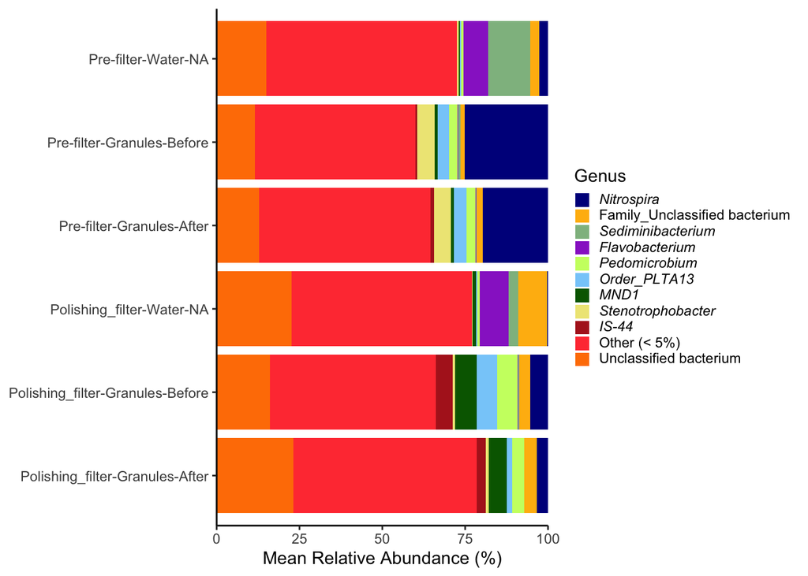

```r
# set colorset
colorset <- c("darkblue", "darkgoldenrod1", "darkseagreen", "darkorchid", "darkolivegreen1", "lightskyblue", "darkgreen",  "khaki2", "firebrick", "brown1", "darkorange1", "cyan1", "royalblue4", "darksalmon", "darkblue", "royalblue4", "dodgerblue3", "steelblue1", "lightskyblue", "darkseagreen", "darkgoldenrod1", "darkseagreen", "darkorchid", "darkolivegreen1", "brown1", "darkorange1", "cyan1", "darkgrey", "darkblue", "darkgoldenrod1", "darkseagreen", "darkorchid", "darkolivegreen1", "lightskyblue", "darkgreen", "deeppink", "khaki2", "firebrick", "brown1", "darkorange1", "cyan1", "royalblue4", "darksalmon", "darkblue", "royalblue4", "dodgerblue3", "steelblue1", "lightskyblue", "darkseagreen", "darkgoldenrod1", "darkseagreen", "darkorchid", "darkolivegreen1", "brown1", "darkorange1", "cyan1", "darkgrey")


#input data
ps_Genus <- psmelt(transform_sample_counts(tax_glom(psdata_OBER, "Genus"), fun = function(x) x/sum(x)))

Genus_abundances <- ps_Genus %>%
  as_tibble() %>%
  select(Sample, Sample_type, Filter_type, Protocol, Time, combined, Genus, Abundance) %>%
  mutate(combined = as.character(combined)) %>%
  group_by(Sample, combined, Genus) %>%
  summarize(rel_abund = sum(Abundance), .groups = "drop") %>%
  group_by(combined, Genus) %>%
  summarize(mean_rel_abund = 100* mean(rel_abund), .groups = "drop") %>%
  mutate(Genus = str_replace(Genus, "(.*)_unclassified", "Unclassified *\\1*"),
         Genus = str_replace(Genus, "uncultured$", "Unclassified bacterium"),
         Genus = str_replace(Genus, "^(\\S*)$", "*\\1*"))


Genus_pool <- Genus_abundances %>%
  group_by(Genus) %>%
  summarize(pool = max(mean_rel_abund) < 5,
            mean = mean(mean_rel_abund),
            .groups = "drop")

library(RColorBrewer)
inner_join(Genus_abundances, Genus_pool, by="Genus") %>%
  mutate(Genus = if_else(pool, "Other (< 5%)", Genus)) %>%
  group_by(combined, Genus) %>%
  summarize(mean_rel_abund = sum(mean_rel_abund),
            mean = min(mean),
            .groups = "drop") %>%
  mutate(Genus = factor(Genus),
         Genus = fct_reorder(Genus, mean, .desc = T),
         Genus = fct_shift(Genus, n=1)) %>%
ggplot(aes(x=combined, y = mean_rel_abund, fill = Genus)) +
  geom_col() +
  scale_y_continuous(expand = c(0,0)) +
  labs(x=NULL, y="Mean Relative Abundance (%)") +
  scale_fill_manual(name="Genus",
                    values = colorset) + #c(rev(brewer.pal(6, "Dark2")), rev(brewer.pal(8, "Paired")))) +

  #                       breaks = c("*Dysgonomonas*",
  #                                  "*Dechlorosoma*",
  #                                  "*Leptolinea*",
  #                                  "*Proteiniphilum*",
  #                                  "*Petrimonas*",
  #                                  "*Geobacter*",
  #                                  "Unclassified bacterium",
  #                                  "Other (< 5%)"),
  #                       values = c(brewer.pal(8,"Paired"), "grey")) + # with palette
  #                       #values = colorset) +
  theme_classic() +
  theme(axis.text.x = element_markdown(),
        legend.text = element_markdown(),
        legend.key.size = unit(10, "pt")) +
  coord_flip()
```

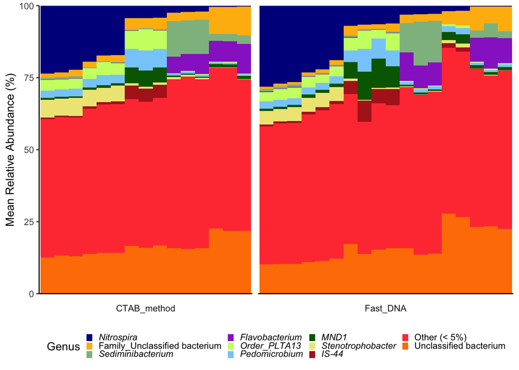

```r
Genus_abundances_sample <- ps_Genus %>%
  as_tibble() %>%
  select(Sample, Sample_type, Filter_type, Protocol, Time, combined, Genus, Abundance) %>%
  mutate(combined = as.character(combined)) %>%
  group_by(Protocol, Sample, combined, Genus) %>%
  summarize(rel_abund = sum(Abundance), .groups = "drop") %>%
  group_by(Protocol, Sample, combined, Genus) %>%
  summarize(mean_rel_abund = 100* mean(rel_abund), .groups = "drop") %>%
  mutate(Genus = str_replace(Genus, "(.*)_unclassified", "Unclassified *\\1*"),
         Genus = str_replace(Genus, "uncultured$", "Unclassified bacterium"),
         Genus = str_replace(Genus, "^(\\S*)$", "*\\1*"))


Genus_pool_sample <- Genus_abundances_sample %>%
  group_by(Sample, combined, Protocol, Genus) %>%
  summarize(mean = mean(mean_rel_abund), .groups = "drop") %>%
  group_by(Genus) %>%
  summarize(pool = max(mean) < 5,
            mean = mean(mean),
            .groups = "drop")

sample_order <- Genus_abundances_sample %>%
  filter(Genus ==  "*Nitrospira*") %>%
  arrange(desc(mean_rel_abund)) %>%
  mutate(order = 1:nrow(.)) %>%
  select(Sample, order)


inner_join(Genus_abundances_sample, Genus_pool_sample, by="Genus") %>%
  mutate(Genus = if_else(pool, "Other (< 5%)", Genus)) %>%
  group_by(Protocol, Sample, combined, Genus) %>%
  summarize(rel_abund = sum(mean_rel_abund),
            mean = min(mean),
            .groups = "drop") %>%
  mutate(Genus = factor(Genus),
         Genus = fct_reorder(Genus, mean, .desc = T),
         Genus = fct_shift(Genus, n=1)) %>%
  inner_join(., sample_order, by = "Sample") %>%
  mutate(Sample = factor(Sample),
         Sample = fct_reorder(Sample, order)) %>%
ggplot(aes(x=Sample, y = rel_abund, fill = Genus)) +
  geom_col(width = 1) +
  scale_fill_manual(name="Genus",
                    values = colorset) +
                        # breaks = c("*Geobacter*",
                        #            "*Dysgonomonas*",
                        #            "*Dechlorosoma*",
                        #            "*Leptolinea*",
                        #            "*Proteiniphilum*",
                        #            "*Petrimonas*",
                        #            "*Family_PHOS-HE36*",
                        #            "Unclassified bacterium",
                        #            "Other (< 5%)"),
                        # values = c(brewer.pal(8,"Paired"),"grey")) + # with palette
                        # #values = colorset) +
  scale_y_continuous(expand = c(0,0)) +
  facet_grid(~Protocol, space = "free", scales = "free_x", switch = "x") +
  labs(x=NULL, y="Mean Relative Abundance (%)") +
  guides(fill = guide_legend(nrow = 3, byrow = F)) +
  theme_classic() +
  theme(axis.text.x = element_blank(),
        legend.text = element_markdown(),
        legend.key.size = unit(7, "pt"),
        axis.ticks.x = element_blank(),
        strip.background = element_blank(),
        strip.placement = "outside",
        legend.position = "bottom")
```

```r
ggsave("figures/OBER_stacked_barplot_Genus.pdf", width = 5, height = 4, units = "in")
```